# Gestion de Portefeuille

TP-4: Simulation d’une gestion selon un Budget Risque

Patrick Hénaff

Février-Mars 2020

L’objet de ce TP est de se familiariser avec les packages de “backtesting” disponibles dans R. pour cela, on propose de reproduire une analyse réalisée avec le package “riskParityPortfolio”, mais en utilisant un nouveau jeu de données, et en portant quelques modifications à l’exemple proposé.

## Le package “riskParityPortfolio”

L’exemple suivant est présenté dans la vignette https://cran.r-project.org/web/packages/riskParityPortfolio/vignettes/RiskParityPortfolio.html

```r
# données de Yahoo! Finance
faang_data <- stockDataDownload(c("GOOG", "NFLX", "AAPL", "AMZN", "FB"),
                                from = "2014-01-01", to = "2019-06-25")
```

pour effectuer un backtest, on définit une fonction qui recoit en entrée une liste de séries de type , et retourne un vecteur de poids aloués à chaque actif. Chaque série de la liste a une colonne par actif. Noter que la liste peut contenir autant de series que necessaire pour exécuter l’algorithme d’allocation. Dans notre cas, on n’a besoin que du cours de cloture ajusté. Cette fonction sera éxécutée de multiples fois, selon les directives données dans la fonction de simulation.

```r
# define portfolios to be backtested
# risk parity portfolio
risk_parity <- function(dataset) {
  prices <- dataset$adjusted
  log_returns <- diff(log(prices))[-1]
  return(riskParityPortfolio(cov(log_returns))$w)
}
```

```r
# tangency portfolio (maximum sharpe ratio)
max_sharpe_ratio <- function(dataset) {
    prices <- dataset$adjusted
    log_returns <- diff(log(prices))[-1]
    N <- ncol(prices)
    Sigma <- cov(log_returns)
    mu <- colMeans(log_returns)
    if (all(mu <= 1e-8))
        return(rep(0, N))
    Dmat <- 2 * Sigma
    Amat <- diag(N)
    Amat <- cbind(mu, Amat)
    bvec <- c(1, rep(0, N))
    dvec <- rep(0, N)
    res <- solve.QP(Dmat = Dmat, dvec = dvec, Amat = Amat, bvec = bvec, meq = 1)
    w <- res$solution
    return(w/sum(w))
}
```

Le backtest lui-même est défini par les paramètres suivants:

- Fenêtre de données historiques à utiliser dans chaque calcul: 240 jours
- Recalcul des poids tous les 60 jours
- Rééquilibrage du portefeuille tous les 60 jours.

On effectue parfois des rééquilibrages entre deux recalculs des poids, pour prendre en compte les mouvements de marché.

```r
# call portfolioBacktest and benchmark against the uniform (1/N) portfolio
bt <- portfolioBacktest(list("risk parity portfolio" = risk_parity,
                             "tangency portfolio"    = max_sharpe_ratio),
                        list(faang_data),
                        T_rolling_window = 12*20,
                        optimize_every = 3*20, rebalance_every = 3*20)
```

Les dates de recalcul:

```
##  [1] "2014-12-12" "2015-03-12" "2015-06-08" "2015-09-01" "2015-11-25"
##  [6] "2016-02-24" "2016-05-19" "2016-08-15" "2016-11-08" "2017-02-06"
## [11] "2017-05-03" "2017-07-28" "2017-10-23" "2018-01-19" "2018-04-17"
## [16] "2018-07-12" "2018-10-05" "2019-01-03" "2019-04-01"
```

Résumé des performances des deux styles de gestion:

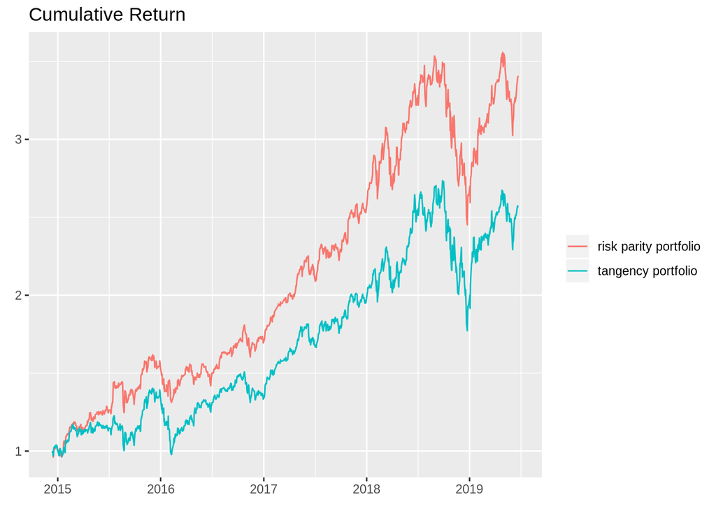

Rendement cumulé

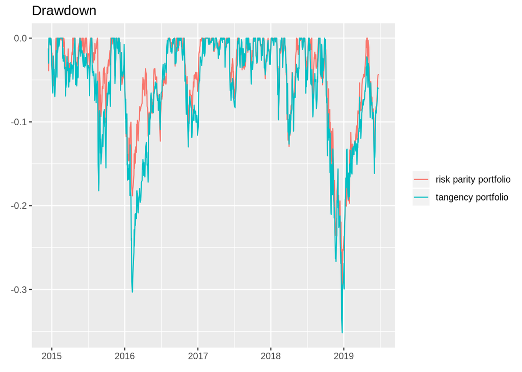

Perte maximale cumulée

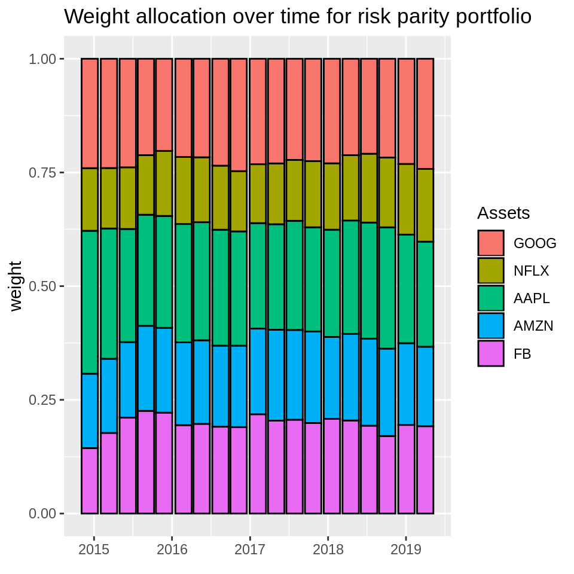

Composition du portefeuille Risk Parity

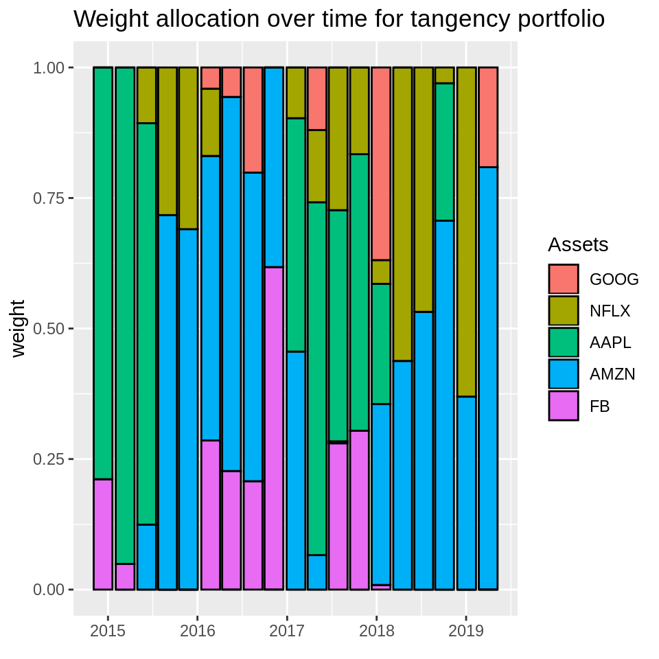

Composition du portefeuille tangent

## Variante 1

Ajouter les contraintes suivantes au portefeuille tangent:

- Poids $<=$ 20%
- Secteur Technologie $<=$ 30%